# Preface

#### Welcome

This is booklet had started off as a hands-on Linux command line guide for new biology students. As I stepped back-and-forth, back-and-forth from that project I realized I was more interested in teaching myself machine learning using R and RStudio.

However, while I was reading on the topic of Linux, I found a quote that describes the philosophy of Unix.

> The Unix philosophy is one of simple tools, each doing one job well…  
> Anonymous

This is **NOT** the philosophy of R nor RStudio. The R library repository, as of April 29, 2019, has more than 14,096 packages. I am still looking for an R package that fits the Unix motto.

#### Who This Book Is For

This book is for me. It is very informal as is my conversational style. It is my record of what I believed would help me in the future. I plan on using this booklet as a template for other data science projects that I will do in the near future.

#### Acknowledgments

I would like to thank Doctors Dmitry Korkine and Elizabeth Ryder for their patience and generosity.

#### Dedication

> To The Socratic Paradox,

> *I know that I know nothing*

#### About the Author

Matthew C. Curcio is a Chemist, Biochemist, Teacher and Student who loves science.

# Prerequisites

As a Bioinformatician, I also consider myself a data scientist. If you are not aware of the ubiquitous Venn diagram of Bioinformatics and Data Science, let’s look at this for a moment.

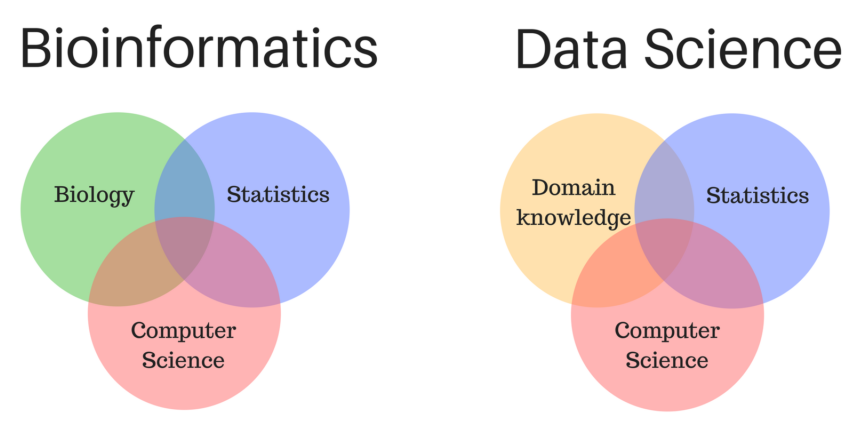

Venn diagram of Bioinformatics and Data Science

To Biologists and Biochemists (which I also consider myself), it is my task to become more familiar with computer languages, miscellaneous concepts and statistics.

#### Regarding the Computing Side

As of the writing of this booklet, Data Science and Bioinformatics are now centered around the computer languages [R](https://cran.r-project.org/) and [Python](https://www.anaconda.com/).

To many researchers in data science and bioinformatics the field now includes such languages as,  
*in no particular order*,

- [R](https://cran.r-project.org/)
- [Python](https://www.anaconda.com/).
- [Bash shell scripting](https://www.datascienceatthecommandline.com/),
- SQL,
- [Julia](https://julialang.org/),
- [Perl](https://www.perl.org/),
- [C](https://en.wikipedia.org/wiki/C_%28programming_language%29),
- [Javascript](https://www.javascript.com/),
- [RMarkdown](https://rmarkdown.rstudio.com/), (this one is fun and easy)

#### Just start with one language**

- Stick with it for a time and learn it. Learn the ins-and-outs of one language first.

#### Is R or Python better?**

1. R & Python are both FREE,
2. Both have great integrated development environments (IDEs),
   - [RStudio](https://www.rstudio.com/) is great & FREE,
   - [Spyder](https://www.spyder-ide.org/) is also great & FREE,
3. Both languages have been around for > 20 years, therefore both have tons of FREE information & tutorials on YouTube,

Ultimately, I chose to start with R because I liked the *community* around it.

## What you will need for this project?

1. An Internet connection,
2. A computer with between 1 & 3 Gigabytes of free hard drive storage,
   - R-Packages & libraries *can take a lot of space*,
3. The program [R](https://cran.r-project.org/),
4. The program [RStudio](https://www.rstudio.com/).

## Download/Install R & RStudio

**NOTE**: I use [Ubuntu](https://www.ubuntu.com/).

1. Go to: https://cran.r-project.org/

[figure not shown]

   https://cran.r-project.org

[figure not shown]

RStudio Home Page

1. From RStudio’s homepage click, *Products* then click *RStudio* from the dropdown menu.
2. Click the Download of the FREE version of RStudio Desktop
3. Click ‘RStudio #.#’ to download a version for your machine

Q. Have Linux? Try this - [How to install RStudio.](https://www.youtube.com/watch?v=LeB15G14N7g)

1. If you are looking for instructions for Mac & Windows machines try:
   - [FreeCodeCamp](https://guide.freecodecamp.org/r/)